# Infant Birth Weight Prediction

# Linsi Lin

## Introduction

Infant birth weight within normal range is a significant indicator for the parents as well as the doctors that the baby is healthy. A significant deviation can be an indication of an abnormality. This dataset set is from a Kaggle competition with 101,399 observations and 36 predictors. For this project, I picked 24 predictors which are infant sex, parents’ age and educational level, completed weeks of gestation, past birth information and some complications that the mother might have, all this information represents the factors from both external and internal factors associated with the mother and her environment. The goal is to find the model that can predict infant birth weight as accurate as possible. On the other hand, it is best to still be able to interpret the significance of each predictor for the infant birth weight.

- Get the Data
- Data Preprocessing
- Exploratory Data Analysis
- Linear Model
  - Linear Model Selection
  - Ridge and Lasso Regression
  - Principle Components Regression and Partial Least Squares
- Non-linear Model
  - Logarithmic Transformation
  - Polynomial Regression
  - Step Functions
  - Cubic Splines
  - Regression Trees
  - Bagging and Random Forests
  - Boosting
- Conclusion

### Variable Names and Descriptions:

FAGE: age of father  
GAINED: weight gained during pregnancy in pounds  
VISITS: number of prenatal visits during the pregnancy  
MAGE: mother's age  
FEDUC: father's years of education  
MEDUC: mother's years of education  
TOTALP: total pregnancies  
BDEAD: number of children born alive now dead  
TERMS: number of other terminations  
WEEKS: completed weeks of gestation  
CIGNUM: average number of cigarettes used daily (Mother)  
DRINKNUM: average number of drinks used daily (mother)  
SEX: sex of the baby (1 is boy and 2 is girl)  
MARITAL: marital status of their parents (1 is married and 2 is unmarried)  
LOUTCOME: outcome of last delivery  
DIABETES: mother has/had diabetes (0 is no and 1 is yes)  
HYDRAM: mother has/had hydramnios/Oligohydramnios (0 is no and 1 is yes)  
HYPERCH: mother has/had chronic hypertension (0 is no and 1 is yes)  
HYPERPR: mother has/had pregnancy hypertension (0 is no and 1 is yes)  
ECLAMP: mother has/had Eclampsia (0 is no and 1 is yes)  
CERVIX: mother has/had incompetent cervix (0 is no and 1 is yes)  
PINFANT: mother has/had previous infant over 8.8 pounds (0 is no and 1 is yes)  
PRETERM: mother has/had previous preterm/small infant (0 is no and 1 is yes)  
UTERINE: mother has/had uterine bleeding (0 is no and 1 is yes)  
BWEIGHT: baby's weight at birth in pounds (response variable)

### Get the Data

```r
suppressWarnings(library(RODBC))
library(ISLR)
library(glmnet)
library(leaps)
library(pls)
library(boot)
library(splines)
library(tree)
library(randomForest)
library(gbm)
library(ggplot2)
library(tidyverse)
library(dplyr)
library(corrplot)
library(knitr)
library(plyr)
library(Rmisc)
library(e1071)
library(robustbase)
library(lmtest)
library(sandwich)
library(VIF)
set.seed(1)
```

```r
infant=read.csv("infant.csv",header=T,na.strings="?")
sum(is.na(infant))
```

0

No missing value!

```r
#change the fitst column
fix(infant)
rownames(infant) = infant[,1]
infant = infant[,-1]
#dimention of the data
dim(infant)
```

1. 101399

2. 25

```r
head(infant)
```

|  | SEX | MARITAL | FAGE | GAINED | VISITS | MAGE | FEDUC | MEDUC | TOTALP | BDEAD | ... | DIABETES | HYDRAM | HYPERCH | HYPERPR | ECLAMP | CERVIX | PINFANT | PRETERM | UTERINE | BWEIGHT |
| --- | --- | --- | --- | --- | --- | --- | --- | --- | --- | --- | --- | --- | --- | --- | --- | --- | --- | --- | --- | --- | --- |
| 2001 | 2 | 1 | 33 | 26 | 10 | 34 | 12 | 4 | 2 | 0 | ... | 0 | 0 | 0 | 0 | 0 | 0 | 0 | 0 | 0 | 4.3750 |
| 2002 | 2 | 2 | 19 | 40 | 10 | 18 | 11 | 12 | 1 | 0 | ... | 0 | 0 | 0 | 0 | 0 | 0 | 0 | 0 | 0 | 6.9375 |
| 2003 | 2 | 1 | 33 | 16 | 14 | 31 | 16 | 16 | 2 | 0 | ... | 0 | 0 | 0 | 0 | 0 | 0 | 0 | 0 | 0 | 8.5000 |
| 2004 | 1 | 1 | 25 | 40 | 15 | 28 | 12 | 12 | 3 | 0 | ... | 0 | 0 | 0 | 0 | 0 | 0 | 0 | 0 | 0 | 8.5000 |
| 2005 | 1 | 2 | 21 | 60 | 13 | 20 | 12 | 14 | 2 | 0 | ... | 0 | 0 | 0 | 1 | 0 | 0 | 0 | 0 | 0 | 9.0000 |
| 2006 | 1 | 1 | 21 | 30 | 15 | 21 | 12 | 13 | 1 | 0 | ... | 0 | 0 | 0 | 0 | 0 | 0 | 0 | 0 | 0 | 8.0000 |

### Data Preprocessing

```r
#convert to categorical variables
infant$SEX <- factor(infant$SEX, levels = c(1,2),labels = c("Boy", "Girl"))
infant$MARITAL <- factor(infant$MARITAL, levels = c(1,2),labels = c("Married", "Unmarried"))
infant$DIABETES<- factor(infant$DIABETES, levels = c(0,1),labels = c("No", "Yes"))
infant$HYDRAM<- factor(infant$HYDRAM, levels = c(0,1),labels = c("No", "Yes"))
infant$HYPERCH<- factor(infant$HYPERCH, levels = c(0,1),labels = c("No", "Yes"))
infant$HYPERPR<- factor(infant$HYPERPR, levels = c(0,1),labels = c("No", "Yes"))
infant$ECLAMP<- factor(infant$ECLAMP, levels = c(0,1),labels = c("No", "Yes"))
infant$CERVIX<- factor(infant$CERVIX, levels = c(0,1),labels = c("No", "Yes"))
infant$PINFANT<- factor(infant$PINFANT, levels = c(0,1),labels = c("No", "Yes"))
infant$PRETERM<- factor(infant$PRETERM, levels = c(0,1),labels = c("No", "Yes"))
infant$UTERINE<- factor(infant$UTERINE, levels = c(0,1),labels = c("No", "Yes"))
infant$LOUTCOME<- factor(infant$LOUTCOME, levels=sort(unique(infant$LOUTCOME)))
summary(infant)
```

```
   SEX             MARITAL           FAGE           GAINED          VISITS
 Boy :52160   Married  :70592   Min.   :14.00   Min.   : 0.00   Min.   : 0.00
 Girl:49239   Unmarried:30807   1st Qu.:25.00   1st Qu.:21.00   1st Qu.:10.00
                                Median :30.00   Median :30.00   Median :12.00
                                Mean   :30.17   Mean   :30.28   Mean   :12.44
                                3rd Qu.:35.00   3rd Qu.:39.00   3rd Qu.:15.00
                                Max.   :74.00   Max.   :98.00   Max.   :49.00
      MAGE           FEDUC           MEDUC           TOTALP
 Min.   :11.00   Min.   : 0.00   Min.   : 0.00   Min.   : 1.000
 1st Qu.:23.00   1st Qu.:12.00   1st Qu.:12.00   1st Qu.: 1.000
 Median :28.00   Median :12.00   Median :13.00   Median : 2.000
 Mean   :27.74   Mean   :12.93   Mean   :13.26   Mean   : 2.378
 3rd Qu.:32.00   3rd Qu.:16.00   3rd Qu.:16.00   3rd Qu.: 3.000
 Max.   :53.00   Max.   :17.00   Max.   :17.00   Max.   :20.000
     BDEAD           TERMS         LOUTCOME      WEEKS           CIGNUM
 Min.   :0.000   Min.   : 0.0000   1:53133   Min.   :18.00   Min.   : 0.000
 1st Qu.:0.000   1st Qu.: 0.0000   2:13750   1st Qu.:38.00   1st Qu.: 0.000
 Median :0.000   Median : 0.0000   9:34516   Median :39.00   Median : 0.000
 Mean   :0.015   Mean   : 0.3716             Mean   :38.74   Mean   : 0.726
 3rd Qu.:0.000   3rd Qu.: 0.0000             3rd Qu.:40.00   3rd Qu.: 0.000
 Max.   :6.000   Max.   :16.0000             Max.   :45.00   Max.   :60.000
    DRINKNUM        DIABETES    HYDRAM      HYPERCH      HYPERPR
 Min.   : 0.00000   No :98046   No :99899   No :100003   No :96325
 1st Qu.: 0.00000   Yes: 3353   Yes: 1500   Yes:  1396   Yes: 5074
 Median : 0.00000
 Mean   : 0.00555
 3rd Qu.: 0.00000
 Max.   :40.00000
 ECLAMP       CERVIX       PINFANT      PRETERM      UTERINE
 No :101013   No :101020   No :100823   No :100501   No :101050
 Yes:   386   Yes:   379   Yes:   576   Yes:   898   Yes:   349




    BWEIGHT
 Min.   : 0.1875
 1st Qu.: 6.6250
 Median : 7.3750
 Mean   : 7.2581
 3rd Qu.: 8.0625
 Max.   :13.0625
```

### Exploratory Data Analysis

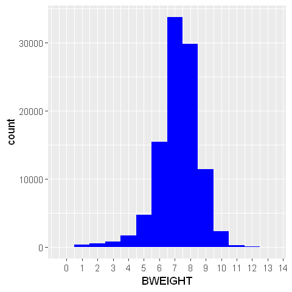

```r
#distribution of response variable (BWEIGHT)
library(repr)
options(repr.plot.width=4, repr.plot.height=4)
ggplot(data=infant, aes(x=BWEIGHT)) +
  geom_histogram(fill="blue", binwidth = 1) +
  scale_x_continuous(breaks= seq(0, 15, by=1))
```

```
There are 13 numeric variables
```

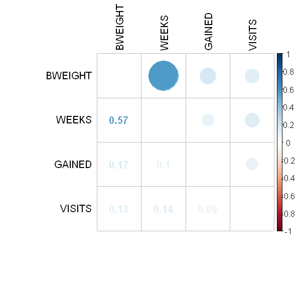

```r
#Correlation between response variable and all numeric varibales, set threshold to 0.1
options(repr.plot.width=5, repr.plot.height=5)
numericVars <- which(sapply(infant, is.numeric)) #index vector numeric variables
numericVarNames <- names(numericVars) #saving names vector for use later on
cat('There are', length(numericVars), 'numeric variables')
infant_numVar <- infant[, numericVars]
cor_numVar <- cor(infant_numVar, use="pairwise.complete.obs") #correlations of infant numeric variables
#sort on decreasing correlations with infant birth weight
cor_sorted <- as.matrix(sort(cor_numVar[,'BWEIGHT'], decreasing = TRUE))
#select only high corelations
CorHigh <- names(which(apply(cor_sorted, 1, function(x) abs(x)>0.1)))
cor_numVar <- cor_numVar[CorHigh, CorHigh]
corrplot.mixed(cor_numVar, tl.col="black", tl.pos = "lt")
```

Among all the numeric variables "WEEKS" is highly correlated with infant birth weight, also note that multicollinearity is not an issue in this dataset

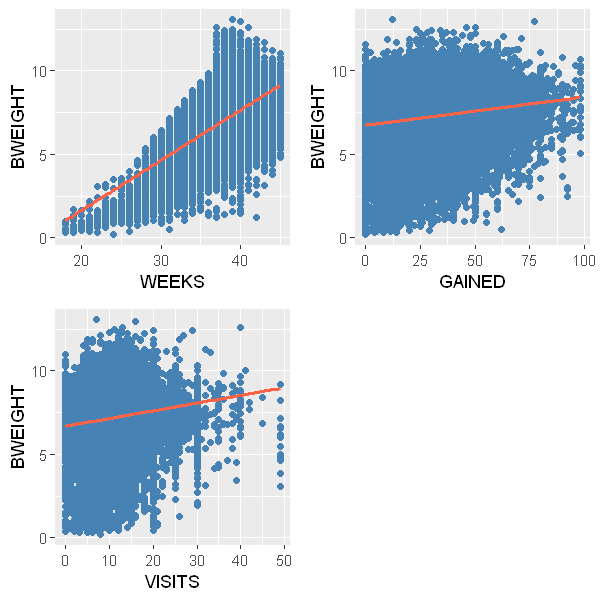

```r
#Plot WEEKS,GAINED,VISITS vs BWEIGHT
q1<-ggplot(data=infant, aes(x=WEEKS, y=BWEIGHT))+
  geom_point(color= "steelblue") + geom_smooth(method = "lm", se=FALSE, color = "tomato", aes(group=5))

q2<-ggplot(data=infant, aes(x=GAINED, y=BWEIGHT))+
  geom_point(color= "steelblue") + geom_smooth(method = "lm", se=FALSE, color = "tomato", aes(group=5))

q3<-ggplot(data=infant, aes(x=VISITS, y=BWEIGHT))+
  geom_point(color= "steelblue") + geom_smooth(method = "lm", se=FALSE, color = "tomato", aes(group=5))
layout <- matrix(c(1,2,3,4),2,2,byrow=TRUE)
multiplot(q1,q2,q3, layout=layout)
```

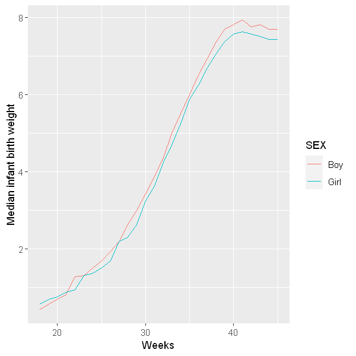

```r
#Infant birth weight between boys and girls amount same weeks
plotdata<-ddply(infant,c("WEEKS","SEX"),summarise,Median_infant_birth_weight=median(BWEIGHT))
ggplot(plotdata,aes(x = WEEKS, y = Median_infant_birth_weight, color = SEX)) +
  geom_line() + xlab("Weeks") + ylab("Median infant birth weight")
#boys are heavier than girls
```

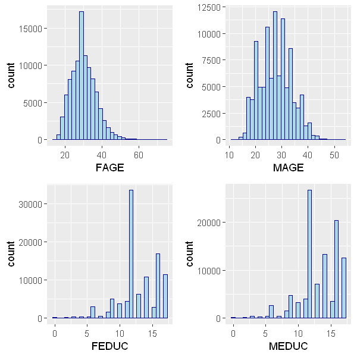

```r
#Numeric variables histogram plot
options(repr.plot.width=5, repr.plot.height=5)
l1<-ggplot(infant, aes(x=FAGE))+
  geom_histogram(color="darkblue", fill="lightblue")
l2<-ggplot(infant, aes(x=MAGE))+
  geom_histogram(color="darkblue", fill="lightblue")
l3<-ggplot(infant, aes(x=FEDUC))+
  geom_histogram(color="darkblue", fill="lightblue")
l4<-ggplot(infant, aes(x=MEDUC))+
  geom_histogram(color="darkblue", fill="lightblue")
layout <- matrix(c(1,2,3,4),2,2,byrow=TRUE)
multiplot(l1,l2,l3,l4, layout=layout)
```

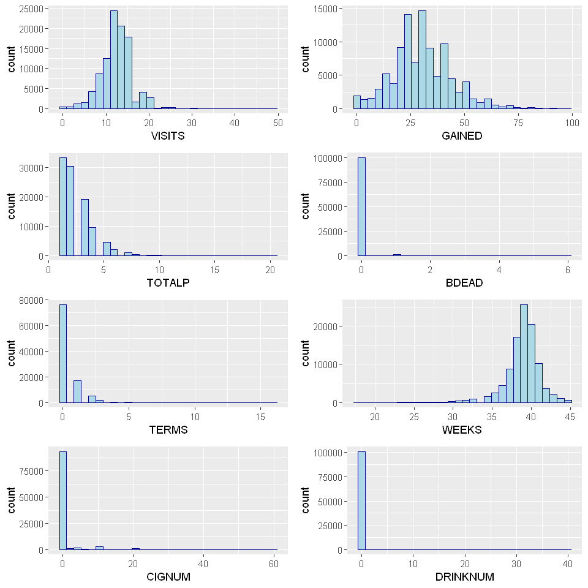

```r
options(repr.plot.width=8, repr.plot.height=8)
l5<-ggplot(infant, aes(x=VISITS))+
  geom_histogram(color="darkblue", fill="lightblue")
l6<-ggplot(infant, aes(x=GAINED))+
  geom_histogram(color="darkblue", fill="lightblue")
l7<-ggplot(infant, aes(x=TOTALP))+
  geom_histogram(color="darkblue", fill="lightblue")
l8<-ggplot(infant, aes(x=BDEAD))+
  geom_histogram(color="darkblue", fill="lightblue")
l9<-ggplot(infant, aes(x=TERMS))+
  geom_histogram(color="darkblue", fill="lightblue")
l10<-ggplot(infant, aes(x=WEEKS))+
  geom_histogram(color="darkblue", fill="lightblue")
l11<-ggplot(infant, aes(x=CIGNUM))+
  geom_histogram(color="darkblue", fill="lightblue")
l12<-ggplot(infant, aes(x=DRINKNUM))+
  geom_histogram(color="darkblue", fill="lightblue")
layout <- matrix(c(1,2,3,4,5,6,7,8),4,2,byrow=TRUE)
multiplot(l5,l6,l7,l8,l9,l10,l11,l12, layout=layout)
```

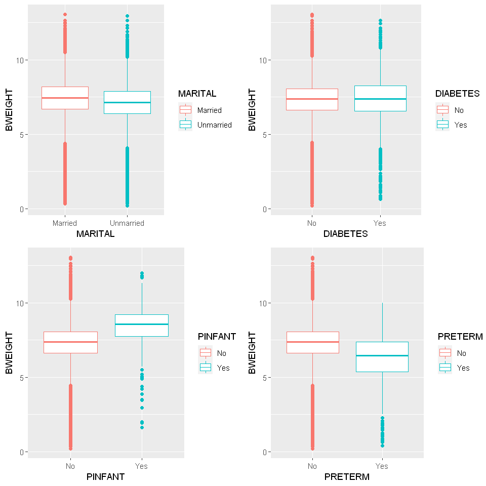

```r
#Explore categorical variables with infant birth weight
p1<-ggplot(infant, aes(x=MARITAL, y=BWEIGHT, color=MARITAL)) +
  geom_boxplot()
p2<-ggplot(infant, aes(x=DIABETES, y=BWEIGHT, color=DIABETES)) +
  geom_boxplot()
p3<-ggplot(infant, aes(x=PINFANT, y=BWEIGHT, color=PINFANT)) +
  geom_boxplot()
p4<-ggplot(infant, aes(x=PRETERM, y=BWEIGHT, color=PRETERM)) +
  geom_boxplot()
layout <- matrix(c(1,2,3,4),2,2,byrow=TRUE)
multiplot(p1,p2,p3,p4, layout=layout)
```

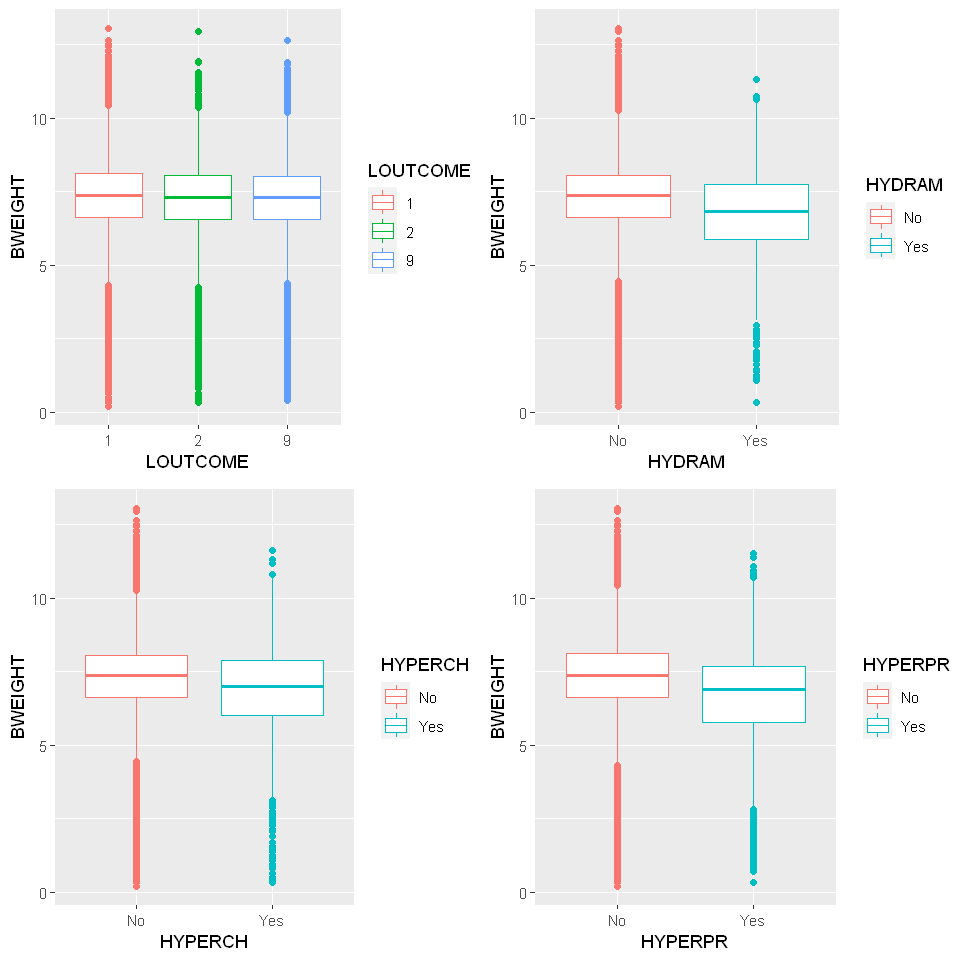

```r
p5<-ggplot(infant, aes(x=LOUTCOME, y=BWEIGHT, color=LOUTCOME)) +
  geom_boxplot()
p6<-ggplot(infant, aes(x=HYDRAM, y=BWEIGHT, color=HYDRAM)) +
  geom_boxplot()
p7<-ggplot(infant, aes(x=HYPERCH, y=BWEIGHT, color=HYPERCH)) +
  geom_boxplot()
p8<-ggplot(infant, aes(x=HYPERPR, y=BWEIGHT, color=HYPERPR)) +
  geom_boxplot()
layout <- matrix(c(1,2,3,4),2,2,byrow=TRUE)
multiplot(p5,p6,p7,p8, layout=layout)
```

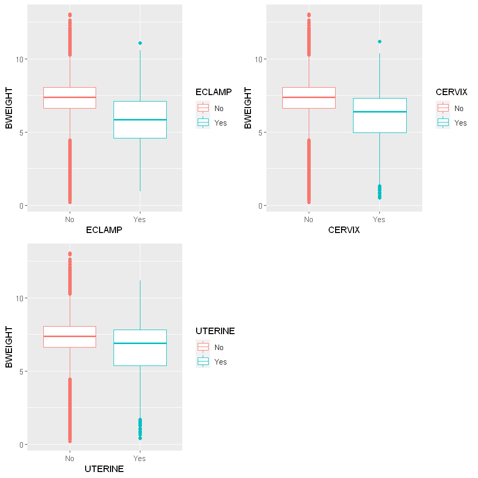

```r
p9<-ggplot(infant, aes(x=ECLAMP, y=BWEIGHT, color=ECLAMP)) +
  geom_boxplot()
p10<-ggplot(infant, aes(x=CERVIX, y=BWEIGHT, color=CERVIX)) +
  geom_boxplot()
p11<-ggplot(infant, aes(x=UTERINE, y=BWEIGHT, color=UTERINE )) +
  geom_boxplot()
layout <- matrix(c(1,2,3,4),2,2,byrow=TRUE)
multiplot(p9,p10,p11, layout=layout)
```

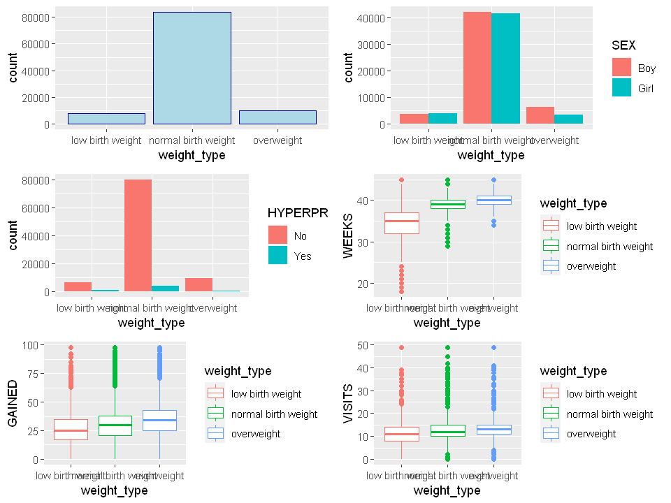

```r
#weight type and weeks
options(repr.plot.width=8, repr.plot.height=6)
weight_range_data<- infant %>%
  mutate(weight_type = case_when(
    BWEIGHT< 5.5 ~ "low birth weight",
    BWEIGHT > 8.8 ~ "overweight",
    TRUE ~ "normal birth weight"
  ))
#histogram for 3 birth weight types
t1<-ggplot(weight_range_data, aes(x=weight_type))+
  geom_bar(color="darkblue", fill="lightblue")
t2<-ggplot(weight_range_data, aes(x = weight_type, fill = SEX)) +
  geom_bar(position = "dodge")
t3<-ggplot(weight_range_data, aes(x = weight_type,fill = HYPERPR)) +
  geom_bar(position = "dodge")
t4<-ggplot(weight_range_data, aes(x=weight_type, y=WEEKS, color=weight_type)) +
  geom_boxplot()
t5<-ggplot(weight_range_data, aes(x=weight_type, y=GAINED, color=weight_type)) +
  geom_boxplot()
t6<-ggplot(weight_range_data, aes(x=weight_type, y=VISITS, color=weight_type)) +
  geom_boxplot()
layout <- matrix(c(1,2,3,4,5,6),3,2,byrow=TRUE)
multiplot(t1,t2,t3,t4,t5,t6, layout=layout)
```

### Linear Model

```
Call:
lm(formula = BWEIGHT ~ ., data = infant)

Residuals:
    Min      1Q  Median      3Q     Max
-6.5478 -0.6696  0.0001  0.6658  5.7927

Coefficients:
                   Estimate Std. Error t value Pr(>|t|)
(Intercept)      -4.4419204  0.0588512 -75.477  < 2e-16 ***
SEXGirl          -0.2655177  0.0065758 -40.378  < 2e-16 ***
MARITALUnmarried -0.1716246  0.0082035 -20.921  < 2e-16 ***
FAGE             -0.0008530  0.0007367  -1.158 0.246930
GAINED            0.0130282  0.0002484  52.450  < 2e-16 ***
VISITS            0.0107707  0.0009277  11.610  < 2e-16 ***
MAGE              0.0111721  0.0009309  12.002  < 2e-16 ***
FEDUC            -0.0063596  0.0017052  -3.730 0.000192 ***
MEDUC             0.0033036  0.0017729   1.863 0.062417 .
TOTALP            0.0379519  0.0042667   8.895  < 2e-16 ***
BDEAD            -0.1437499  0.0240176  -5.985 2.17e-09 ***
TERMS            -0.0659972  0.0070287  -9.390  < 2e-16 ***
LOUTCOME2        -0.0452999  0.0125396  -3.613 0.000303 ***
LOUTCOME9        -0.1596704  0.0098804 -16.160  < 2e-16 ***
WEEKS             0.2877879  0.0013566 212.137  < 2e-16 ***
CIGNUM           -0.0326816  0.0011209 -29.157  < 2e-16 ***
DRINKNUM         -0.0018217  0.0158210  -0.115 0.908333
DIABETESYes       0.2759147  0.0186167  14.821  < 2e-16 ***
HYDRAMYes        -0.3413281  0.0272522 -12.525  < 2e-16 ***
HYPERCHYes       -0.2186825  0.0284270  -7.693 1.45e-14 ***
HYPERPRYes       -0.3439736  0.0152971 -22.486  < 2e-16 ***
ECLAMPYes        -0.6501162  0.0536382 -12.120  < 2e-16 ***
CERVIXYes        -0.4365996  0.0542580  -8.047 8.59e-16 ***
PINFANTYes        0.9330495  0.0438495  21.278  < 2e-16 ***
PRETERMYes       -0.4623945  0.0354035 -13.061  < 2e-16 ***
UTERINEYes       -0.3124886  0.0561667  -5.564 2.65e-08 ***
---
Signif. codes:  0 '***' 0.001 '**' 0.01 '*' 0.05 '.' 0.1 ' ' 1

Residual standard error: 1.046 on 101373 degrees of freedom
Multiple R-squared:  0.3815,	Adjusted R-squared:  0.3813
F-statistic:  2501 on 25 and 101373 DF,  p-value: < 2.2e-16
```

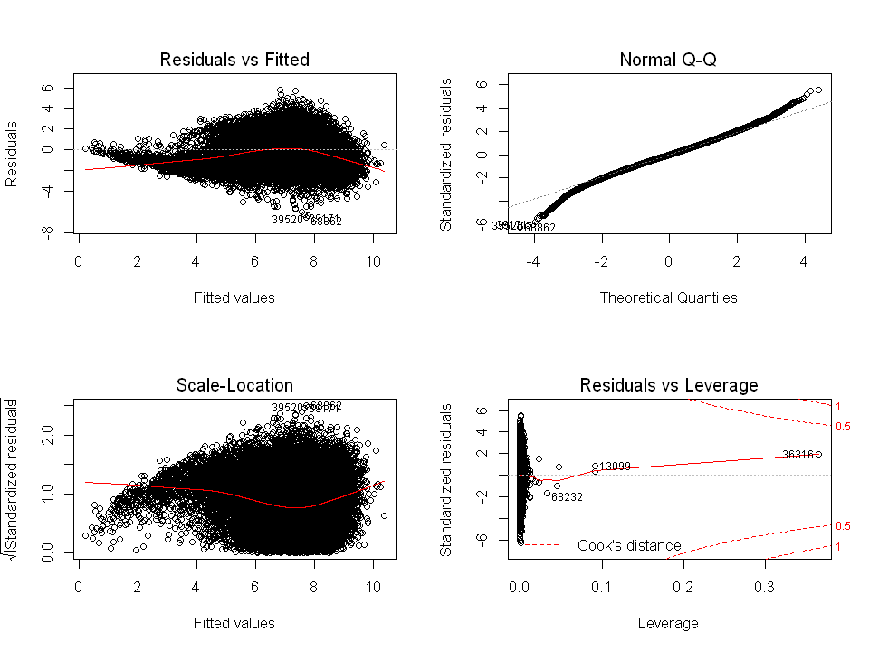

```r
#Linear model
par(mfrow=c(2,2))
lm.fit=lm(BWEIGHT~.,data=infant)
summary(lm.fit)
plot(lm.fit)
```

Residual plots are a useful graphical tool for identifying non-linearity. The redline is a smooth fit to the residuals, intended to make it easier to identify a trend. Ideally, the residual plot will show no fitted discernible pattern. But we can see that the red line is somewhat curved in the graph and the there shows non-constant variance. The presence of the discernable pattern indicates that the true relationship between infant birth weight and all predictors may not be truly linear.

```r
#check heteroscedasticity
lmtest::bptest(lm.fit)  # Breusch-Pagan test
```

```
	studentized Breusch-Pagan test

data:  lm.fit
BP = 1208.6, df = 25, p-value < 2.2e-16
```

BP test shows the p-value is less than the significance level 0.05, therefore we can reject the null hypothesis that the variance of the residuals is constant and infer that heteroscedasticity is indeed present which confirm what we observe from the graph above.

```r
#fix heteroscedasticity
coeftest(lm.fit, vcov = vcovHC(lm.fit, type="HC1"))
```

```
t test of coefficients:

                    Estimate  Std. Error  t value  Pr(>|t|)
(Intercept)      -4.44192036  0.07067827 -62.8470 < 2.2e-16 ***
SEXGirl          -0.26551768  0.00656804 -40.4257 < 2.2e-16 ***
MARITALUnmarried -0.17162459  0.00826256 -20.7714 < 2.2e-16 ***
FAGE             -0.00085303  0.00074915  -1.1387 0.2548508
GAINED            0.01302818  0.00026333  49.4743 < 2.2e-16 ***
VISITS            0.01077068  0.00100405  10.7272 < 2.2e-16 ***
MAGE              0.01117207  0.00095624  11.6833 < 2.2e-16 ***
FEDUC            -0.00635964  0.00170921  -3.7208 0.0001987 ***
MEDUC             0.00330358  0.00181812   1.8170 0.0692154 .
TOTALP            0.03795190  0.00455564   8.3308 < 2.2e-16 ***
BDEAD            -0.14374987  0.02739267  -5.2477 1.543e-07 ***
TERMS            -0.06599722  0.00741603  -8.8993 < 2.2e-16 ***
LOUTCOME2        -0.04529993  0.01289348  -3.5134 0.0004426 ***
LOUTCOME9        -0.15967045  0.01000096 -15.9655 < 2.2e-16 ***
WEEKS             0.28778792  0.00169589 169.6968 < 2.2e-16 ***
CIGNUM           -0.03268163  0.00117058 -27.9191 < 2.2e-16 ***
DRINKNUM         -0.00182165  0.01925654  -0.0946 0.9246334
DIABETESYes       0.27591466  0.02160766  12.7693 < 2.2e-16 ***
HYDRAMYes        -0.34132814  0.03058735 -11.1591 < 2.2e-16 ***
HYPERCHYes       -0.21868250  0.03273970  -6.6794 2.411e-11 ***
HYPERPRYes       -0.34397364  0.01750205 -19.6533 < 2.2e-16 ***
ECLAMPYes        -0.65011622  0.06713452  -9.6838 < 2.2e-16 ***
CERVIXYes        -0.43659965  0.05663396  -7.7091 1.278e-14 ***
PINFANTYes        0.93304953  0.04942341  18.8787 < 2.2e-16 ***
PRETERMYes       -0.46239454  0.03642231 -12.6954 < 2.2e-16 ***
UTERINEYes       -0.31248858  0.05879647  -5.3148 1.070e-07 ***
---
Signif. codes:  0 '***' 0.001 '**' 0.01 '*' 0.05 '.' 0.1 ' ' 1
```

The coeffient doesn't change, only standard error changes.Good for interpretaion.

```r
skewness(infant$BWEIGHT)
```

-0.936554483334065

Skewness is a measure of the symmetry in a distribution. A symmetrical dataset will have a skewness equal to 0. So, a normal distribution will have a skewness of 0. Skewness essentially measures the relative size of the two tails. As a rule of thumb, skewness should be between -1 and 1.

```r
attach(infant)
train=sample(1:nrow(infant),nrow(infant)*0.8)
lm.fit=lm(BWEIGHT~.,data=infant,subset=train)
#test MSE using linear regression
mean((BWEIGHT-predict(lm.fit,infant))[-train]^2)
```

1.0916989549209

#### Linear Model Selection

The true model may not be linear, but we can use Linear Model Selection and Regularization to get an idea of what predictors are most significant as we will need to use those predictors for non-linear methods.

```r
#####################################################
#Best Subset,Forward and Backward Stepwise Selection
#####################################################
regfit.full=regsubsets(BWEIGHT~.,data=infant) #best subset selection
summary(regfit.full)
regfit.fwd=regsubsets(BWEIGHT~.,data=infant,nvmax=8,method="forward")
summary(regfit.fwd)
regfit.bwd=regsubsets(BWEIGHT~.,data=infant,nvmax=8,method="backward")
summary(regfit.bwd)
```

```
Subset selection object
Call: regsubsets.formula(BWEIGHT ~ ., data = infant)
25 Variables  (and intercept)
                 Forced in Forced out
SEXGirl              FALSE      FALSE
MARITALUnmarried     FALSE      FALSE
FAGE                 FALSE      FALSE
GAINED               FALSE      FALSE
VISITS               FALSE      FALSE
MAGE                 FALSE      FALSE
FEDUC                FALSE      FALSE
MEDUC                FALSE      FALSE
TOTALP               FALSE      FALSE
BDEAD                FALSE      FALSE
TERMS                FALSE      FALSE
LOUTCOME2            FALSE      FALSE
LOUTCOME9            FALSE      FALSE
WEEKS                FALSE      FALSE
CIGNUM               FALSE      FALSE
DRINKNUM             FALSE      FALSE
DIABETESYes          FALSE      FALSE
HYDRAMYes            FALSE      FALSE
HYPERCHYes           FALSE      FALSE
HYPERPRYes           FALSE      FALSE
ECLAMPYes            FALSE      FALSE
CERVIXYes            FALSE      FALSE
PINFANTYes           FALSE      FALSE
PRETERMYes           FALSE      FALSE
UTERINEYes           FALSE      FALSE
1 subsets of each size up to 8
Selection Algorithm: exhaustive
         SEXGirl MARITALUnmarried FAGE GAINED VISITS MAGE FEDUC MEDUC TOTALP
1  ( 1 ) " "     " "              " "  " "    " "    " "  " "   " "   " "
2  ( 1 ) " "     " "              " "  "*"    " "    " "  " "   " "   " "
3  ( 1 ) " "     " "              " "  "*"    " "    "*"  " "   " "   " "
4  ( 1 ) "*"     " "              " "  "*"    " "    "*"  " "   " "   " "
5  ( 1 ) "*"     " "              " "  "*"    " "    "*"  " "   " "   " "
6  ( 1 ) "*"     "*"              " "  "*"    " "    " "  " "   " "   " "
7  ( 1 ) "*"     "*"              " "  "*"    " "    " "  " "   " "   " "
8  ( 1 ) "*"     "*"              " "  "*"    " "    " "  " "   " "   " "
```

[output cut: 12 more lines]

```
3  ( 1 ) " "       " "        " "        " "       " "       " "
4  ( 1 ) " "       " "        " "        " "       " "       " "
5  ( 1 ) " "       " "        " "        " "       " "       " "
6  ( 1 ) " "       " "        " "        " "       " "       " "
7  ( 1 ) " "       " "        "*"        " "       " "       " "
8  ( 1 ) " "       " "        "*"        " "       " "       "*"
         PRETERMYes UTERINEYes
1  ( 1 ) " "        " "
2  ( 1 ) " "        " "
3  ( 1 ) " "        " "
4  ( 1 ) " "        " "
5  ( 1 ) " "        " "
6  ( 1 ) " "        " "
7  ( 1 ) " "        " "
8  ( 1 ) " "        " "
```

```
Subset selection object
Call: regsubsets.formula(BWEIGHT ~ ., data = infant, nvmax = 8, method = "forward")
25 Variables  (and intercept)
                 Forced in Forced out
SEXGirl              FALSE      FALSE
MARITALUnmarried     FALSE      FALSE
FAGE                 FALSE      FALSE
GAINED               FALSE      FALSE
VISITS               FALSE      FALSE
MAGE                 FALSE      FALSE
FEDUC                FALSE      FALSE
MEDUC                FALSE      FALSE
TOTALP               FALSE      FALSE
BDEAD                FALSE      FALSE
TERMS                FALSE      FALSE
LOUTCOME2            FALSE      FALSE
LOUTCOME9            FALSE      FALSE
WEEKS                FALSE      FALSE
CIGNUM               FALSE      FALSE
DRINKNUM             FALSE      FALSE
DIABETESYes          FALSE      FALSE
HYDRAMYes            FALSE      FALSE
HYPERCHYes           FALSE      FALSE
HYPERPRYes           FALSE      FALSE
ECLAMPYes            FALSE      FALSE
CERVIXYes            FALSE      FALSE
PINFANTYes           FALSE      FALSE
PRETERMYes           FALSE      FALSE
UTERINEYes           FALSE      FALSE
1 subsets of each size up to 8
Selection Algorithm: forward
         SEXGirl MARITALUnmarried FAGE GAINED VISITS MAGE FEDUC MEDUC TOTALP
1  ( 1 ) " "     " "              " "  " "    " "    " "  " "   " "   " "
2  ( 1 ) " "     " "              " "  "*"    " "    " "  " "   " "   " "
3  ( 1 ) " "     " "              " "  "*"    " "    "*"  " "   " "   " "
4  ( 1 ) "*"     " "              " "  "*"    " "    "*"  " "   " "   " "
5  ( 1 ) "*"     " "              " "  "*"    " "    "*"  " "   " "   " "
6  ( 1 ) "*"     " "              " "  "*"    " "    "*"  " "   " "   " "
7  ( 1 ) "*"     " "              " "  "*"    " "    "*"  " "   " "   " "
8  ( 1 ) "*"     "*"              " "  "*"    " "    "*"  " "   " "   " "
```

[output cut: 12 more lines]

```
3  ( 1 ) " "       " "        " "        " "       " "       " "
4  ( 1 ) " "       " "        " "        " "       " "       " "
5  ( 1 ) " "       " "        " "        " "       " "       " "
6  ( 1 ) " "       " "        " "        " "       " "       " "
7  ( 1 ) " "       " "        "*"        " "       " "       " "
8  ( 1 ) " "       " "        "*"        " "       " "       " "
         PRETERMYes UTERINEYes
1  ( 1 ) " "        " "
2  ( 1 ) " "        " "
3  ( 1 ) " "        " "
4  ( 1 ) " "        " "
5  ( 1 ) " "        " "
6  ( 1 ) " "        " "
7  ( 1 ) " "        " "
8  ( 1 ) " "        " "
```

```
Subset selection object
Call: regsubsets.formula(BWEIGHT ~ ., data = infant, nvmax = 8, method = "backward")
25 Variables  (and intercept)
                 Forced in Forced out
SEXGirl              FALSE      FALSE
MARITALUnmarried     FALSE      FALSE
FAGE                 FALSE      FALSE
GAINED               FALSE      FALSE
VISITS               FALSE      FALSE
MAGE                 FALSE      FALSE
FEDUC                FALSE      FALSE
MEDUC                FALSE      FALSE
TOTALP               FALSE      FALSE
BDEAD                FALSE      FALSE
TERMS                FALSE      FALSE
LOUTCOME2            FALSE      FALSE
LOUTCOME9            FALSE      FALSE
WEEKS                FALSE      FALSE
CIGNUM               FALSE      FALSE
DRINKNUM             FALSE      FALSE
DIABETESYes          FALSE      FALSE
HYDRAMYes            FALSE      FALSE
HYPERCHYes           FALSE      FALSE
HYPERPRYes           FALSE      FALSE
ECLAMPYes            FALSE      FALSE
CERVIXYes            FALSE      FALSE
PINFANTYes           FALSE      FALSE
PRETERMYes           FALSE      FALSE
UTERINEYes           FALSE      FALSE
1 subsets of each size up to 8
Selection Algorithm: backward
         SEXGirl MARITALUnmarried FAGE GAINED VISITS MAGE FEDUC MEDUC TOTALP
1  ( 1 ) " "     " "              " "  " "    " "    " "  " "   " "   " "
2  ( 1 ) " "     " "              " "  "*"    " "    " "  " "   " "   " "
3  ( 1 ) "*"     " "              " "  "*"    " "    " "  " "   " "   " "
4  ( 1 ) "*"     "*"              " "  "*"    " "    " "  " "   " "   " "
5  ( 1 ) "*"     "*"              " "  "*"    " "    " "  " "   " "   " "
6  ( 1 ) "*"     "*"              " "  "*"    " "    " "  " "   " "   " "
7  ( 1 ) "*"     "*"              " "  "*"    " "    " "  " "   " "   " "
8  ( 1 ) "*"     "*"              " "  "*"    " "    " "  " "   " "   " "
```

[output cut: 12 more lines]

```
3  ( 1 ) " "       " "        " "        " "       " "       " "
4  ( 1 ) " "       " "        " "        " "       " "       " "
5  ( 1 ) " "       " "        " "        " "       " "       " "
6  ( 1 ) " "       " "        " "        " "       " "       " "
7  ( 1 ) " "       " "        "*"        " "       " "       " "
8  ( 1 ) " "       " "        "*"        " "       " "       "*"
         PRETERMYes UTERINEYes
1  ( 1 ) " "        " "
2  ( 1 ) " "        " "
3  ( 1 ) " "        " "
4  ( 1 ) " "        " "
5  ( 1 ) " "        " "
6  ( 1 ) " "        " "
7  ( 1 ) " "        " "
8  ( 1 ) " "        " "
```

8

8

8

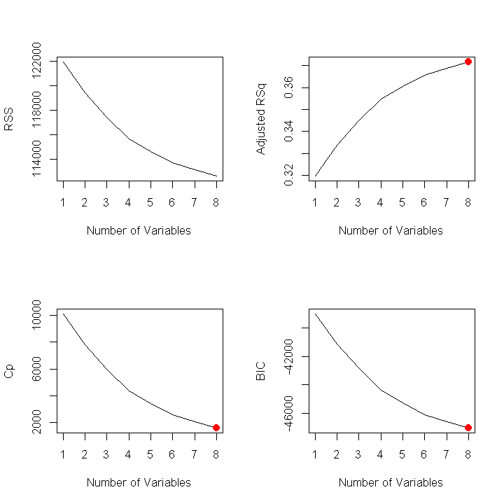

```r
#pick the best number of variables based on best subset model
par(mfrow=c(2,2))
options(repr.plot.width=6, repr.plot.height=6)
reg.summary=summary(regfit.full)
plot(reg.summary$rss,xlab="Number of Variables",ylab="RSS",type="l")
plot(reg.summary$adjr2,xlab="Number of Variables",ylab="Adjusted RSq",type="l")
which.max(reg.summary$adjr2)
points(8,reg.summary$adjr2[8], col="red",cex=2,pch=20)
plot(reg.summary$cp,xlab="Number of Variables",ylab="Cp",type='l')
which.min(reg.summary$cp)
points(8,reg.summary$cp[8],col="red",cex=2,pch=20)
which.min(reg.summary$bic)
plot(reg.summary$bic,xlab="Number of Variables",ylab="BIC",type='l')
points(8,reg.summary$bic[8],col="red",cex=2,pch=20)
#the best pick would be 8
```

```r
#find coefficients for 3 variable selection models
Bestsubset=coef(regfit.full,8)
Bestsubset
Forward=coef(regfit.fwd,8)
Forward
Backward=coef(regfit.bwd,8)
Backward
```

**(Intercept)**

-4.15485246660654

**SEXGirl**

-0.265811302129086

**MARITALUnmarried**

-0.234145754639792

**GAINED**

0.0126205278807931

**LOUTCOME9**

-0.219450244221286

**WEEKS**

0.292810216906117

**CIGNUM**

-0.0342663832592838

**HYPERPRYes**

-0.343039922182311

**PINFANTYes**

0.970927735437068

**(Intercept)**

-4.57731240515562

**SEXGirl**

-0.265414808701154

**MARITALUnmarried**

-0.177977000508542

**GAINED**

0.0128240032020566

**MAGE**

0.0122458636531991

**LOUTCOME9**

-0.187031208342675

**WEEKS**

0.294189632423221

**CIGNUM**

-0.0333873951940971

**HYPERPRYes**

-0.347160649774246

**(Intercept)**

-4.15485246660637

**SEXGirl**

-0.265811302129086

**MARITALUnmarried**

-0.234145754639793

**GAINED**

0.0126205278807931

**LOUTCOME9**

-0.219450244221285

**WEEKS**

0.292810216906113

**CIGNUM**

-0.0342663832592837

**HYPERPRYes**

-0.343039922182308

**PINFANTYes**

0.970927735437056

Best subset selection and backward selection choose the same best eight predictors.  
Forward selection picks seven same predictors with only one predictor MAGE being different. One thing to note that WEEKS and GAINED are two most significant predictors as they were included in the three models throughout the eight-steps. It will be very useful information when trying to perform non-linear methods for the data either by adding interaction terms or adding polynomials.

#### Ridge and Lasso Regression

```r
##################################
##Ridge regression
##################################
par(mfrow=c(1,1))
attach(infant)
x=model.matrix(BWEIGHT~.,infant)[,-1]
y=infant$BWEIGHT
train=sample(1:nrow(infant),nrow(infant)*0.8)
test=(-train)
y.test=y[test]
#Ridge Regression
grid=10^seq(10,-2,length=100)
ridge.mod=glmnet(x,y,alpha=0,lambda=grid)
ridge.mod=glmnet(x[train,],y[train],alpha=0,lambda=grid, thresh=1e-12)
#we can use CV to choose the tuning parameter lambda
cv.out=cv.glmnet(x[train,],y[train],alpha=0)
bestlam=cv.out$lambda.min
bestlam
```

0.075481907543234

```r
ridge.pred=predict(ridge.mod,s=bestlam,newx=x[test,])
mean((ridge.pred-y.test)^2)#test MSE
```

1.11187347513621

```r
#refit on teh full data set, using the "best" lambda
out=glmnet(x,y,alpha=0)
predict(out,type="coefficients",s=bestlam)[1:24,]
#note:none of beta.hat are zero!
```

**(Intercept)**

-3.83147157169231

**SEXGirl**

-0.250342045500498

**MARITALUnmarried**

-0.16556549417062

**FAGE**

6.89082076723327e-05

**GAINED**

0.0124614617252757

**VISITS**

0.0117797547029523

**MAGE**

0.0100289610014009

**FEDUC**

-0.00506988218233857

**MEDUC**

0.00252128595642989

**TOTALP**

0.0321466740523137

**BDEAD**

-0.139783717825421

**TERMS**

-0.0562196445024574

**LOUTCOME2**

-0.0480293051612437

**LOUTCOME9**

-0.152861543497339

**WEEKS**

0.272051873467861

**CIGNUM**

-0.0310547954461487

**DRINKNUM**

-0.00466135455875442

**DIABETESYes**

0.251986775662804

**HYDRAMYes**

-0.331814798469282

**HYPERCHYes**

-0.221285007887354

**HYPERPRYes**

-0.341815889967188

**ECLAMPYes**

-0.65123805879059

**CERVIXYes**

-0.464343747305379

**PINFANTYes**

0.897905457161001

```r
##################################
##Lasso regression
##################################
lasso.mod=glmnet(x[train,],y[train],alpha=1,lambda=grid)
#plot(lasso.mod)#coefficient plot
cv.out=cv.glmnet(x[train,],y[train],alpha=1)
#plot(cv.out)#CV error plot
bestlam=cv.out$lambda.1se
bestlam
```

0.0166447473793643

```r
lasso.pred=predict(lasso.mod,s=bestlam,newx=x[test,])
mean((lasso.pred-y.test)^2) #test MSE
```

1.1186341504521

```r
out=glmnet(x,y,alpha=1,lambda=grid)
lasso.coef=predict(out,type="coefficients",s=bestlam)[1:24,]
#lasso.coef
lasso.coef[lasso.coef!=0]
```

**(Intercept)**

-4.22554861050704

**SEXGirl**

-0.232853749059063

**MARITALUnmarried**

-0.148125424086256

**GAINED**

0.0114411421243619

**VISITS**

0.00637727853380887

**MAGE**

0.00989309262118178

**TOTALP**

0.00135893117858577

**BDEAD**

-0.00395846475962237

**TERMS**

-0.0056036938098477

**LOUTCOME2**

-0.0364563520726355

**LOUTCOME9**

-0.159685688047522

**WEEKS**

0.284829348367189

**CIGNUM**

-0.0276088394508295

**DIABETESYes**

0.167756761563967

**HYDRAMYes**

-0.218347392252561

**HYPERCHYes**

-0.0681663420450038

**HYPERPRYes**

-0.27439870990183

**ECLAMPYes**

-0.411337381257051

**CERVIXYes**

-0.219869615322811

**PINFANTYes**

0.752599116850306

#### Principle Components Regression and Partial Least Squares

1.11098084166648

```
Data: 	X dimension: 101399 25
	Y dimension: 101399 1
Fit method: svdpc
Number of components considered: 21
TRAINING: % variance explained
   1 comps  2 comps  3 comps  4 comps  5 comps  6 comps  7 comps  8 comps
X  12.1770   21.925   27.450    32.44    36.91    41.22    45.38    49.46
y   0.3362    2.113    6.625    19.32    20.37    22.57    27.02    27.45
   9 comps  10 comps  11 comps  12 comps  13 comps  14 comps  15 comps
X    53.49     57.49     61.43     65.30     69.14     72.91     76.60
y    27.49     27.97     28.20     28.55     29.35     29.79     29.94
   16 comps  17 comps  18 comps  19 comps  20 comps  21 comps
X     80.25     83.77     87.08     90.05     92.78     95.23
y     31.65     32.23     32.52     37.71     37.84     38.07
```

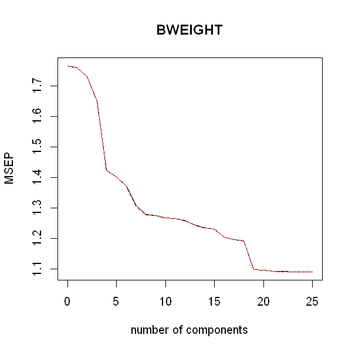

```r
###########################################################
#Principal Components Regression and Partial Least Squares
##########################################################
#Fitting on training, use CV found the best number of principal components
options(repr.plot.width=5, repr.plot.height=5)
pcr.fit=pcr(BWEIGHT~., data=infant,subset=train,scale=TRUE, validation="CV")
validationplot(pcr.fit,val.type="MSEP")
#the lowest CV error occurs when M=21
pcr.pred=predict(pcr.fit,x[test,],ncomp=21)
mean((pcr.pred-y.test)^2) #test MSE

pcr.fit=pcr(y~x,scale=TRUE,ncomp=21)#refit on the whole data
summary(pcr.fit)
```

1.11049900160279

```
Data: 	X dimension: 101399 25
	Y dimension: 101399 1
Fit method: kernelpls
Number of components considered: 4
TRAINING: % variance explained
         1 comps  2 comps  3 comps  4 comps
X          5.993    14.94    22.22    30.07
BWEIGHT   34.352    37.58    38.03    38.12
```

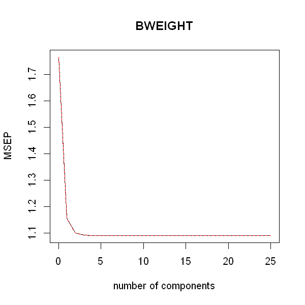

```r
#Partial Least Squares
#fit pls using training data
pls.fit=plsr(BWEIGHT~., data=infant,subset=train,scale=TRUE, validation="CV")
pls.pred=predict(pls.fit,x[test,],ncomp=4)
mean((pls.pred-y.test)^2)

#the lowest CV error occurs around M=4
validationplot(pls.fit,val.type="MSEP")
pls.fit=plsr(BWEIGHT~., data=infant,scale=TRUE,ncomp=4)
summary(pls.fit)
```

### Non-linear Model

#### Logarithmic Transformation

```
Call:
lm(formula = log(BWEIGHT) ~ ., data = infant)

Residuals:
     Min       1Q   Median       3Q      Max
-2.71268 -0.08879  0.01324  0.10701  0.66115

Coefficients:
                   Estimate Std. Error t value Pr(>|t|)
(Intercept)      -4.277e-01  9.828e-03 -43.520  < 2e-16 ***
SEXGirl          -3.797e-02  1.098e-03 -34.575  < 2e-16 ***
MARITALUnmarried -2.453e-02  1.370e-03 -17.905  < 2e-16 ***
FAGE             -1.993e-04  1.230e-04  -1.620  0.10529
GAINED            2.053e-03  4.148e-05  49.488  < 2e-16 ***
VISITS            2.600e-03  1.549e-04  16.782  < 2e-16 ***
MAGE              1.604e-03  1.554e-04  10.317  < 2e-16 ***
FEDUC            -8.941e-04  2.848e-04  -3.140  0.00169 **
MEDUC             2.186e-04  2.961e-04   0.738  0.46026
TOTALP            6.993e-03  7.125e-04   9.815  < 2e-16 ***
BDEAD            -3.632e-02  4.011e-03  -9.055  < 2e-16 ***
TERMS            -1.139e-02  1.174e-03  -9.704  < 2e-16 ***
LOUTCOME2        -1.006e-02  2.094e-03  -4.805 1.55e-06 ***
LOUTCOME9        -2.849e-02  1.650e-03 -17.270  < 2e-16 ***
WEEKS             5.924e-02  2.265e-04 261.493  < 2e-16 ***
CIGNUM           -4.606e-03  1.872e-04 -24.608  < 2e-16 ***
DRINKNUM          1.350e-03  2.642e-03   0.511  0.60944
DIABETESYes       4.618e-02  3.109e-03  14.855  < 2e-16 ***
HYDRAMYes        -5.074e-02  4.551e-03 -11.150  < 2e-16 ***
HYPERCHYes       -3.922e-02  4.747e-03  -8.262  < 2e-16 ***
HYPERPRYes       -4.974e-02  2.554e-03 -19.471  < 2e-16 ***
ECLAMPYes        -1.132e-01  8.957e-03 -12.643  < 2e-16 ***
CERVIXYes        -1.238e-01  9.061e-03 -13.666  < 2e-16 ***
PINFANTYes        1.133e-01  7.322e-03  15.475  < 2e-16 ***
PRETERMYes       -6.970e-02  5.912e-03 -11.790  < 2e-16 ***
UTERINEYes       -8.933e-02  9.379e-03  -9.524  < 2e-16 ***
---
Signif. codes:  0 '***' 0.001 '**' 0.01 '*' 0.05 '.' 0.1 ' ' 1

Residual standard error: 0.1746 on 101373 degrees of freedom
Multiple R-squared:  0.4636,	Adjusted R-squared:  0.4634
F-statistic:  3504 on 25 and 101373 DF,  p-value: < 2.2e-16
```

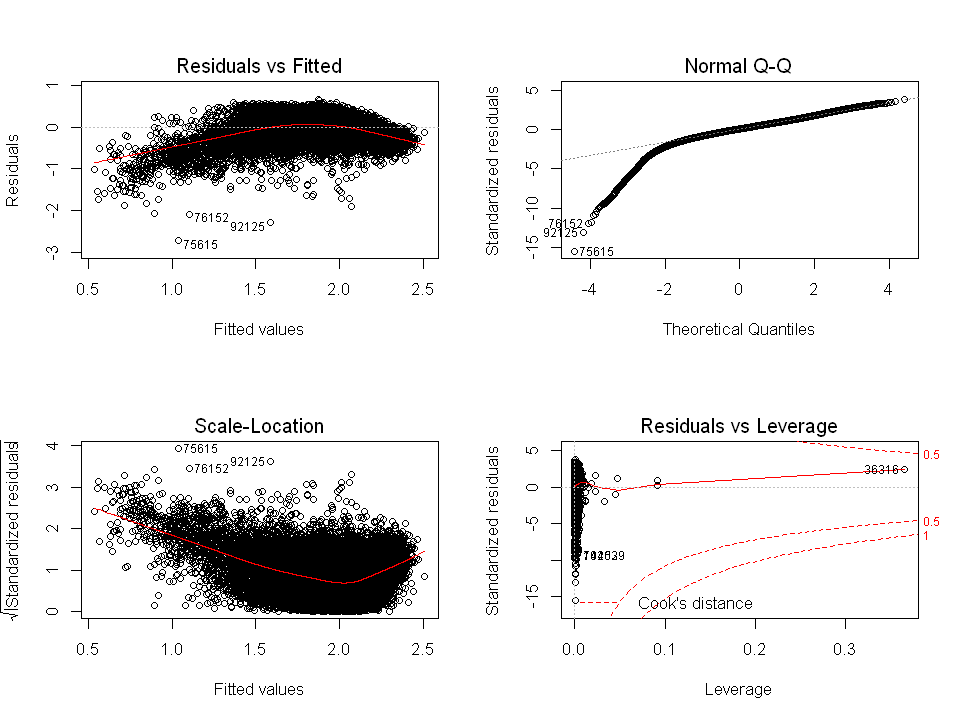

```r
########################
# Non-linear Modeling
#######################
#log transformation
options(repr.plot.width=8, repr.plot.height=6)
par(mfrow=c(2,2))
lm.fit=lm(log(BWEIGHT)~.,data=infant)
summary(lm.fit)
plot(lm.fit)
```

```r
lm.fit=lm(log(BWEIGHT)~.,data=infant,subset = train)
exp(mean((log(BWEIGHT)-predict(lm.fit,infant))[-train]^2))
```

1.03092487714701

#### Polynomial Regression

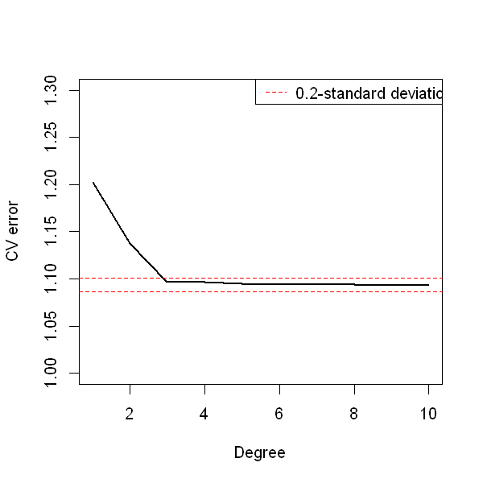

```r
#use k-fold to choose the optimal degree d for the polynomial and plot
options(repr.plot.width=5, repr.plot.height=5)
all.deltas = rep(NA, 10)
for (i in 1:10) {
  glm.fit = glm(BWEIGHT~poly(WEEKS, i), data=infant)
  all.deltas[i] = cv.glm(infant, glm.fit, K=10)$delta[2]
}
plot(1:10, all.deltas, xlab="Degree", ylab="CV error", type="l", pch=20, lwd=2, ylim=c(1,1.3))
min.point = min(all.deltas)
sd.points = sd(all.deltas)
abline(h=min.point + 0.2 * sd.points, col="red", lty="dashed")
abline(h=min.point - 0.2 * sd.points, col="red", lty="dashed")
legend("topright", "0.2-standard deviation lines", lty="dashed", col="red")
#Degree 3 appears to provide a reasonable fit to the data
```

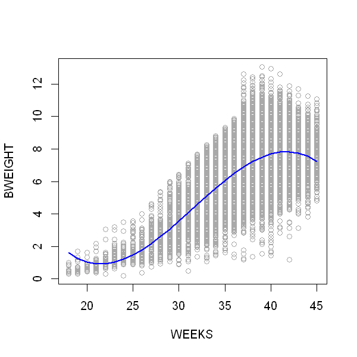

```r
#now plot the polynomial prediction on the data
plot(BWEIGHT~WEEKS, data=infant, col="darkgrey")
WEEKSlims = range(infant$WEEKS)
WEEKS.grid = seq(from=WEEKSlims[1], to=WEEKSlims[2])
lm.fit = lm(BWEIGHT~poly(WEEKS, 3), data=infant)
lm.pred = predict(lm.fit, data.frame(WEEKS=WEEKS.grid))
lines(WEEKS.grid, lm.pred, col="blue", lwd=2)
```

```r
#find test MSE
lm.fit=lm(BWEIGHT~.+poly(WEEKS, 3),data=infant,subset = train)
summary(lm.fit)
mean((BWEIGHT-predict(lm.fit,infant))[-train]^2)
```

```
Call:
lm(formula = BWEIGHT ~ . + poly(WEEKS, 3), data = infant, subset = train)

Residuals:
    Min      1Q  Median      3Q     Max
-6.4117 -0.6488 -0.0222  0.6223  5.5469

Coefficients: (1 not defined because of singularities)
                   Estimate Std. Error t value Pr(>|t|)
(Intercept)      -4.436e+00  6.290e-02 -70.525  < 2e-16 ***
SEXGirl          -2.609e-01  7.031e-03 -37.108  < 2e-16 ***
MARITALUnmarried -1.557e-01  8.781e-03 -17.731  < 2e-16 ***
FAGE             -1.718e-03  7.858e-04  -2.186 0.028816 *
GAINED            1.203e-02  2.661e-04  45.191  < 2e-16 ***
VISITS            5.373e-03  9.920e-04   5.416 6.11e-08 ***
MAGE              1.079e-02  9.942e-04  10.851  < 2e-16 ***
FEDUC            -6.384e-03  1.820e-03  -3.507 0.000453 ***
MEDUC             1.993e-03  1.898e-03   1.050 0.293754
TOTALP            3.554e-02  4.557e-03   7.800 6.29e-15 ***
BDEAD            -9.588e-02  2.598e-02  -3.690 0.000224 ***
TERMS            -5.947e-02  7.494e-03  -7.936 2.11e-15 ***
LOUTCOME2        -3.295e-02  1.338e-02  -2.463 0.013797 *
LOUTCOME9        -1.348e-01  1.056e-02 -12.770  < 2e-16 ***
WEEKS             2.910e-01  1.449e-03 200.806  < 2e-16 ***
CIGNUM           -3.111e-02  1.196e-03 -26.008  < 2e-16 ***
DRINKNUM          3.783e-03  1.553e-02   0.244 0.807489
DIABETESYes       2.609e-01  1.977e-02  13.194  < 2e-16 ***
HYDRAMYes        -3.216e-01  2.896e-02 -11.105  < 2e-16 ***
HYPERCHYes       -1.882e-01  3.037e-02  -6.197 5.79e-10 ***
HYPERPRYes       -3.122e-01  1.638e-02 -19.053  < 2e-16 ***
ECLAMPYes        -5.488e-01  5.790e-02  -9.478  < 2e-16 ***
CERVIXYes        -2.547e-01  5.847e-02  -4.356 1.32e-05 ***
PINFANTYes        9.270e-01  4.733e-02  19.588  < 2e-16 ***
PRETERMYes       -3.579e-01  3.780e-02  -9.466  < 2e-16 ***
UTERINEYes       -1.430e-01  6.065e-02  -2.357 0.018420 *
poly(WEEKS, 3)1          NA         NA      NA       NA
poly(WEEKS, 3)2  -7.344e+01  1.128e+00 -65.122  < 2e-16 ***
poly(WEEKS, 3)3  -6.191e+01  1.122e+00 -55.185  < 2e-16 ***
---
Signif. codes:  0 '***' 0.001 '**' 0.01 '*' 0.05 '.' 0.1 ' ' 1

Residual standard error: 0.9998 on 81091 degrees of freedom
Multiple R-squared:  0.434,	Adjusted R-squared:  0.4338
F-statistic:  2303 on 27 and 81091 DF,  p-value: < 2.2e-16
```

1.02165203305714

#### Step Function

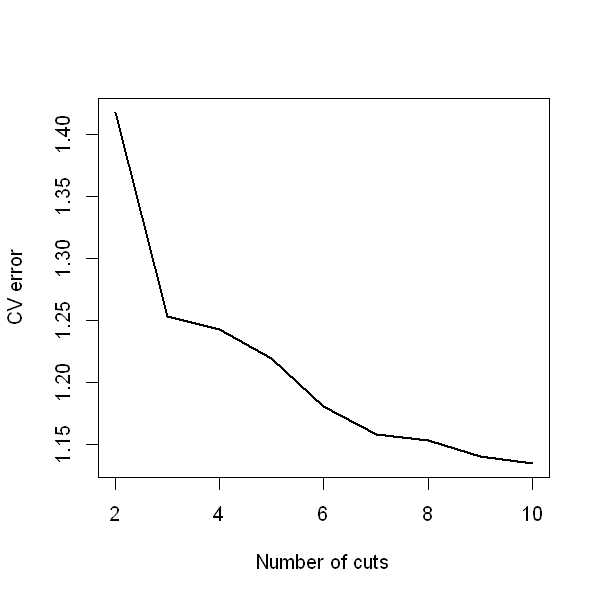

```r
#Step function
#use k-fold cv to choose best cuts
all.cvs = rep(NA, 10)
for (i in 2:10) {
  infant$WEEKS.cut = cut(infant$WEEKS, i)
  lm.fit = glm(BWEIGHT~WEEKS.cut, data=infant)
  all.cvs[i] = cv.glm(infant, lm.fit, K=10)$delta[2]
}
plot(2:10, all.cvs[-1], xlab="Number of cuts", ylab="CV error", type="l", pch=20, lwd=2)
```

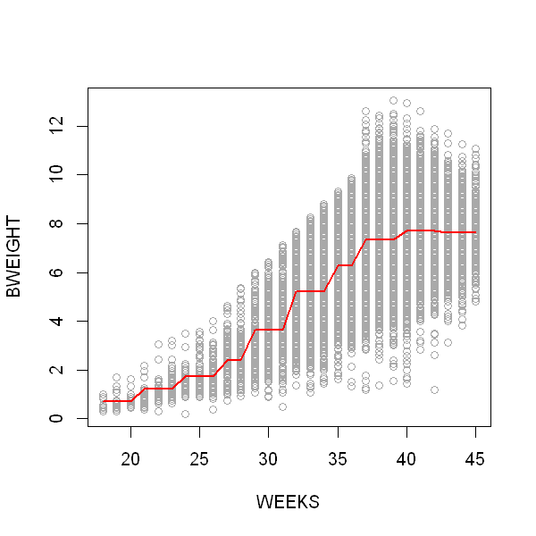

```r
#now train the entire data with step function using 10 cuts and plot it.
lm.fit = glm(BWEIGHT~cut(WEEKS, 10), data=infant)
WEEKSlims = range(infant$WEEKS)
WEEKS.grid = seq(from=WEEKSlims[1], to=WEEKSlims[2])
lm.pred = predict(lm.fit, data.frame(WEEKS=WEEKS.grid))
plot(BWEIGHT~WEEKS, data=infant, col="darkgrey")
lines(WEEKS.grid, lm.pred, col="red", lwd=2)
```

```r
#check the test error
lm.fit=lm(BWEIGHT~.+cut(WEEKS, 10), data=infant,subset = train)
mean((BWEIGHT-predict(lm.fit,infant))[-train]^2)
```

1.03104044935313

#### Cubic Splines

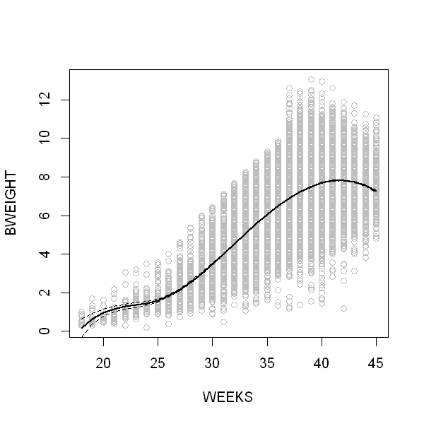

```r
# Cubic Splines
#bs() function generates the matrix of basis functions for splines
#with the specified set of knots. By default, cubic splinse are produced
lm.fit=lm(BWEIGHT~bs(WEEKS,knots=c(15,25,35,45)),data=infant)
pred=predict(lm.fit,newdata=list(WEEKS=WEEKS.grid),se=T)
plot(WEEKS,BWEIGHT,col="gray")
lines(WEEKS.grid,pred$fit,lwd=2)
lines(WEEKS.grid,pred$fit+2*pred$se,lty="dashed")
lines(WEEKS.grid,pred$fit-2*pred$se,lty="dashed")
```

```r
lm.fit=lm(BWEIGHT~bs(WEEKS,knots=c(15,20,25,30,35,40,45)),data=infant,subset = train)
mean((BWEIGHT-predict(lm.fit,infant))[-train]^2)
```

1.12163658620429

#### Regression Trees

```
Regression tree:
tree(formula = BWEIGHT ~ ., data = infant, subset = train)
Variables actually used in tree construction:
[1] "WEEKS"
Number of terminal nodes:  5
Residual mean deviance:  1.125 = 91230 / 81110
Distribution of residuals:
    Min.  1st Qu.   Median     Mean  3rd Qu.     Max.
-6.45800 -0.70820 -0.02074  0.00000  0.66680  5.65000
```

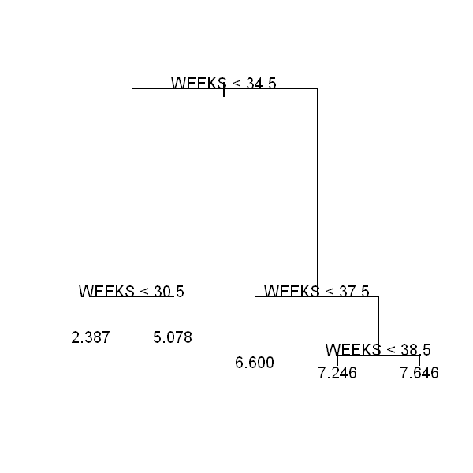

```r
#################
#Decision trees
#################
#Regression Trees
tree.infant=tree(BWEIGHT~.,infant,subset=train)
summary(tree.infant)
plot(tree.infant)
text(tree.infant,pretty=0)
```

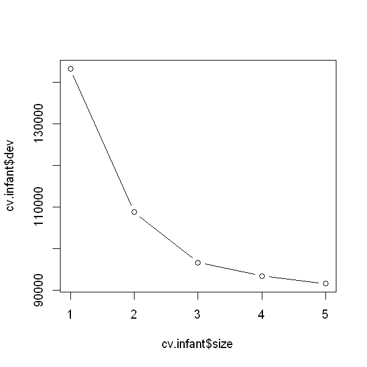

```r
#in regression, deviance is the RSS
cv.infant=cv.tree(tree.infant)
plot(cv.infant$size,cv.infant$dev,type='b')
```

1.16216909245524

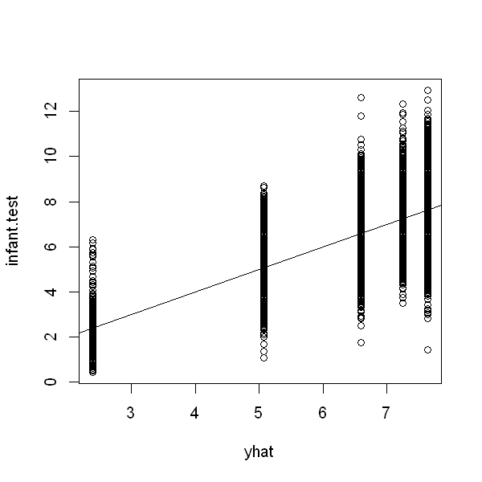

```r
yhat=predict(tree.infant,newdata=infant[-train,])
infant.test=infant[-train,"BWEIGHT"]
plot(yhat,infant.test)
abline(0,1)
mean((yhat-infant.test)^2)
```

#### Bagging and Random Forest

Bagging will use all 24 predictors while Random Forest uses square root of all 24 predictors, that is around 5 predictors. Random Forest is just a special case of Bagging where the method tries to decorrelate the trees.

```r
#Bagging
bag.infant=randomForest(BWEIGHT~.,data=infant,subset=train,mtry=24,ntree=15,importance=TRUE)
bag.infant
yhat.bag = predict(bag.infant,newdata=infant[-train,])
#plot(yhat.bag, infant.test)
#abline(0,1)
mean((yhat.bag-infant.test)^2)
```

```
Call:
 randomForest(formula = BWEIGHT ~ ., data = infant, mtry = 24,      ntree = 15, importance = TRUE, subset = train)
               Type of random forest: regression
                     Number of trees: 15
No. of variables tried at each split: 24

          Mean of squared residuals: 1.21612
                    % Var explained: 31.11
```

1.10962761406018

1.05216134275753

|  | %IncMSE | IncNodePurity |
| --- | --- | --- |
| SEX | 11.3785731 | 1640.00062 |
| MARITAL | 12.2720592 | 1315.87367 |
| FAGE | 14.6220199 | 7740.37587 |
| GAINED | 33.3141228 | 10367.83347 |
| VISITS | 9.1154421 | 7468.46252 |
| MAGE | 22.1282790 | 7471.09635 |
| FEDUC | 26.1814351 | 4850.04693 |
| MEDUC | 21.0629529 | 5099.79180 |
| TOTALP | 8.8898635 | 3322.11780 |
| BDEAD | 1.1559141 | 344.34499 |
| TERMS | 5.9550367 | 1862.12689 |
| LOUTCOME | 10.1823037 | 1609.13709 |
| WEEKS | 10.6210870 | 35526.77746 |
| CIGNUM | 17.5684979 | 1915.45669 |
| DRINKNUM | 0.8395205 | 96.83607 |
| DIABETES | 7.3494876 | 792.92903 |
| HYDRAM | 2.7382119 | 543.79625 |
| HYPERCH | 3.8310557 | 399.29859 |
| HYPERPR | 8.5163815 | 1168.25648 |
| ECLAMP | 3.3727051 | 227.57158 |
| CERVIX | 0.4753805 | 129.96199 |
| PINFANT | 13.0091975 | 504.87354 |
| PRETERM | 2.9054686 | 329.84983 |
| UTERINE | 0.9705705 | 133.60566 |
| WEEKS.cut | 5.4041805 | 19052.22040 |

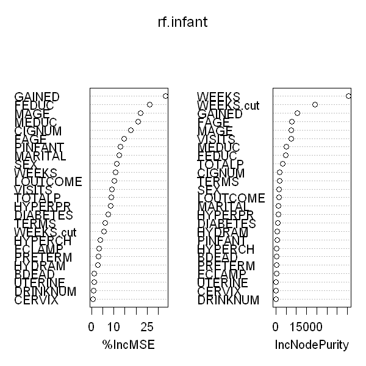

```r
#Random Forest
rf.infant=randomForest(BWEIGHT~.,data=infant,subset=train,mtry=5,ntree=15,importance=TRUE)
yhat.rf = predict(rf.infant,newdata=infant[-train,])
mean((yhat.rf-infant.test)^2)

#view the importance of each variable
importance(rf.infant)
varImpPlot(rf.infant)
```

#### Boosting

|  | var | rel.inf |
| --- | --- | --- |
| WEEKS | WEEKS | 71.27633568 |
| WEEKS.cut | WEEKS.cut | 9.39893458 |
| GAINED | GAINED | 4.55093255 |
| SEX | SEX | 2.18388214 |
| CIGNUM | CIGNUM | 2.00213074 |
| MAGE | MAGE | 1.61573543 |
| MARITAL | MARITAL | 1.07752527 |
| VISITS | VISITS | 1.06896761 |
| LOUTCOME | LOUTCOME | 1.04531812 |
| FAGE | FAGE | 0.87191711 |
| PINFANT | PINFANT | 0.73328658 |
| HYPERPR | HYPERPR | 0.69964973 |
| MEDUC | MEDUC | 0.65855236 |
| FEDUC | FEDUC | 0.59702004 |
| TOTALP | TOTALP | 0.56094523 |
| DIABETES | DIABETES | 0.42471666 |
| HYDRAM | HYDRAM | 0.25904084 |
| ECLAMP | ECLAMP | 0.20711348 |
| TERMS | TERMS | 0.20618812 |
| PRETERM | PRETERM | 0.18594217 |
| HYPERCH | HYPERCH | 0.14069017 |
| BDEAD | BDEAD | 0.11518760 |
| CERVIX | CERVIX | 0.06249128 |
| DRINKNUM | DRINKNUM | 0.03267230 |
| UTERINE | UTERINE | 0.02482421 |

1.00105329948037

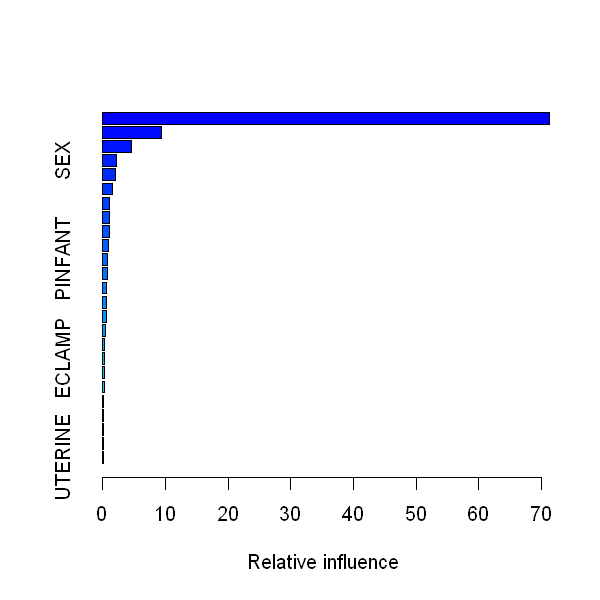

```r
#Boosting
boost.infant=gbm(BWEIGHT~.,data=infant[train,],distribution="gaussian",n.trees=500,interaction.depth=4)
#produces influence plot and influence statistics
summary(boost.infant)

yhat.boost = predict(boost.infant,newdata=infant[-train,],n.trees=500)
mean((yhat.boost-infant.test)^2)
```

Summary plot

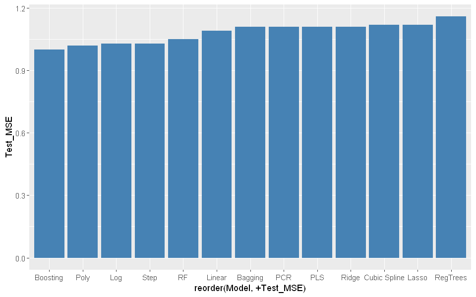

```r
#summary of test MSE for all models
# Create data
options(repr.plot.width = 8, repr.plot.height = 5)
data <- data.frame(
  Model=c("Linear","Ridge","Lasso","PCR","PLS","Log","Poly","Step","Cubic Spline","RegTrees","Bagging","RF","Boosting") ,
  Test_MSE=c(1.09,1.11,1.12,1.11,1.11,1.03,1.02,1.03,1.12,1.16,1.11,1.05,1)
)

# Barplot
ggplot(data, aes(x = reorder(Model, +Test_MSE), y = Test_MSE)) +
         geom_bar(stat = "identity",fill="steelblue")
```